# ESG (FP1)

Orianna Wang

9/14/2022

## Research questions

How water scarcity may make an impact on a corporate’s financial performance (e.g. bonds)?

How does climate change impact agriculture and food prices?

Will climate change affect global trade (eg. import of necessities)?

## Data 1: IFC Investment By Industry - Annual Summary

### Data source:

Provided by World Bank Group. IFC Industries (Sectors) are in charge of processing IFC transactions.

### Data description:

The data shows the amount of money in millions of dollars the international finance cooperation investment on the commercial bases to different industries.

### Variable names:

fiscal year: The fiscal year begins on July 1st of the previous year and runs through June 30th of the designated year. Agribusiness and Forestry: investment in the industry of Agribusiness and Forestry in millions of USD. Natural Resources: investment in the industry of Natural Resources in millions of USD.

### Data visualization:

```r
library(dplyr)
library(tidyverse)
```

```r
library(ggplot2)
library(leaflet)
IFC <- read_csv("IFC/IFC_Investment_By_Industry_-_Annual_Summary.csv")
IFC <- IFC[,1:6]
IFC
```

```
## # A tibble: 12 × 6
##    `Fiscal Year` `Agribusiness a…` `Telecommunica…` Manufacturing Infrastructure
##            <dbl>             <dbl>            <dbl>         <dbl>          <dbl>
##  1          2010              727              442          1240           1904
##  2          2011              512.             337.          830.          1621.
##  3          2012             1021.             247.         1021.          1447.
##  4          2013             1278.             472.         1314.          2247.
##  5          2014             1051              489           984           2426
##  6          2015             1375.             275.          365.          2056.
##  7          2016             1062              541           824           1813
##  8          2017             1155              232           989           1705
##  9          2018              956              207           536           2073
## 10          2019              501              131           534           1056
## 11          2020             1054               21           664           1415
## 12          2021             1009              601           833           1045
## # … with 1 more variable: `Natural Resources` <dbl>
```

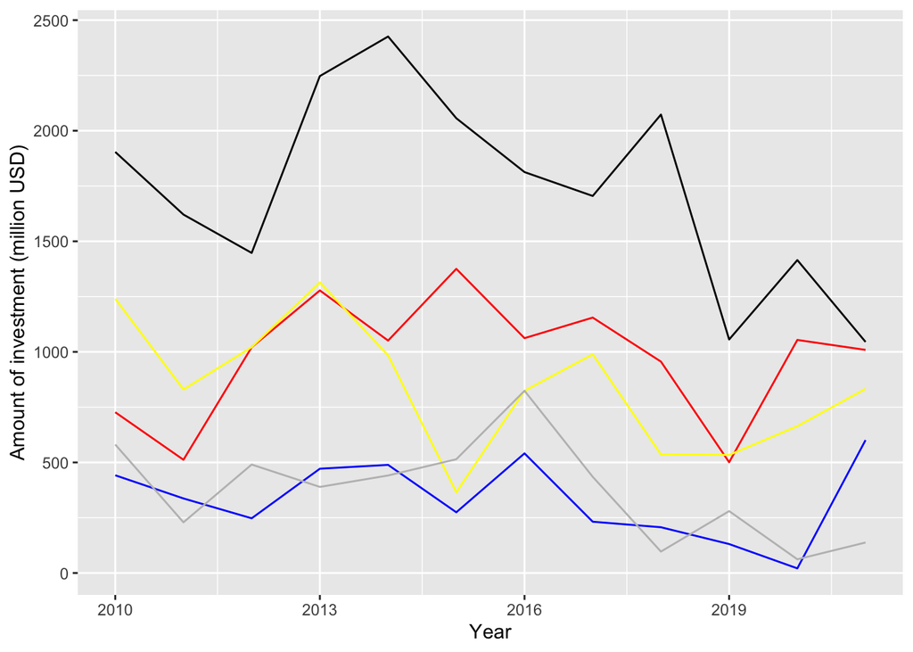

```r
IFC %>%
  ggplot() +
  geom_line(aes(x = `Fiscal Year`,
                y = `Agribusiness and Forestry`),
            color = "red") +
  geom_line(aes(x = `Fiscal Year`,
                y = `Telecommunications and Information Technologies`),
            color = "blue") +
  geom_line(aes(x = `Fiscal Year`,
                y = `Manufacturing`),
            color ="yellow") +
  geom_line(aes(x = `Fiscal Year`,
                y = `Infrastructure`)) +
  geom_line(aes(x = `Fiscal Year`,
                y = `Natural Resources`),
            color="grey") +
  labs(x = "Year",
       y = "Amount of investment (million USD)")
```

## Data 2: Agricultural land

### Data source

food and Agriculture Organization, electronic files and web site.

### Data description

Agricultural land refers to the share of land area that is arable, under permanent crops, and under permanent pastures.

### Data limitations

the data is updated to 2018, lack recent data, but the data is not too old to lack analysis value. It contains agriculture land as a percentage of land area for each country, which is what I need.

### Variable names

Country Name: the name of each country 1961: the agriculture land as a percentage of land area for each country in 1961. …same for each year

### Data visualization

```r
agriculture <- read_csv("arguculture/Argiculture.csv")
```

```
## * `` -> ...3
## * `` -> ...4
## * `` -> ...5
## * `` -> ...6
## * `` -> ...7
## * ...
```

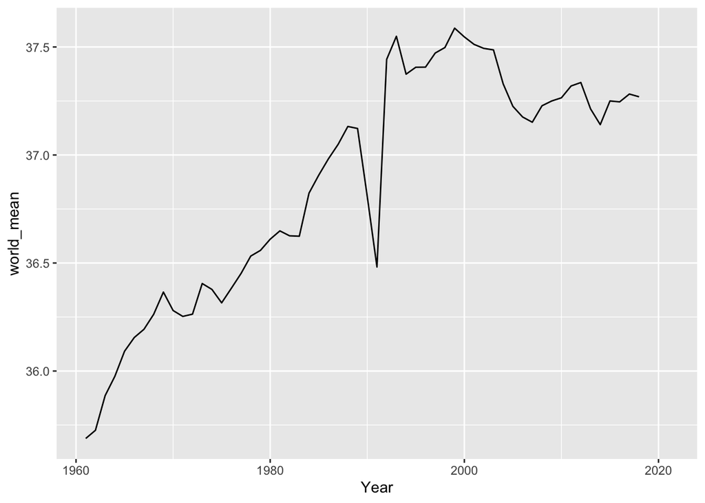

```r
agr_clean <- agriculture %>%
  tail(-4) %>%
  select(-c(...3, ...4, ...5)) %>%
  pivot_longer(cols =starts_with("..."),
               names_to = "year",
               values_to = "Value")

agr_clean %>%
  cbind(Year = as.numeric(substring(agr_clean$year, 4))) %>%
  mutate(Year = Year + 1955) %>%
  select(`Data Source`, Year, Value) %>%
  group_by(Year) %>%
  summarise(world_mean = mean(Value, na.rm = TRUE)) %>%
  ggplot(aes(x = Year,
             y = world_mean),
         show.legend = FALSE) +
  geom_line()
```

Indicate some variable or variables that can connect at least two of the dataset in a join. You do not need to actually do the join, just figure out which variables would be helpful.

### Connection:

we can connect the investment in Agribusiness and Forestry change and the global average agriculture land use change to see the trend of agriculture with respect to time.